# Assignment 2 Solutions

### Problems

1. The following code makes a histogram of the `duration` variable in the Lake Monona data set.

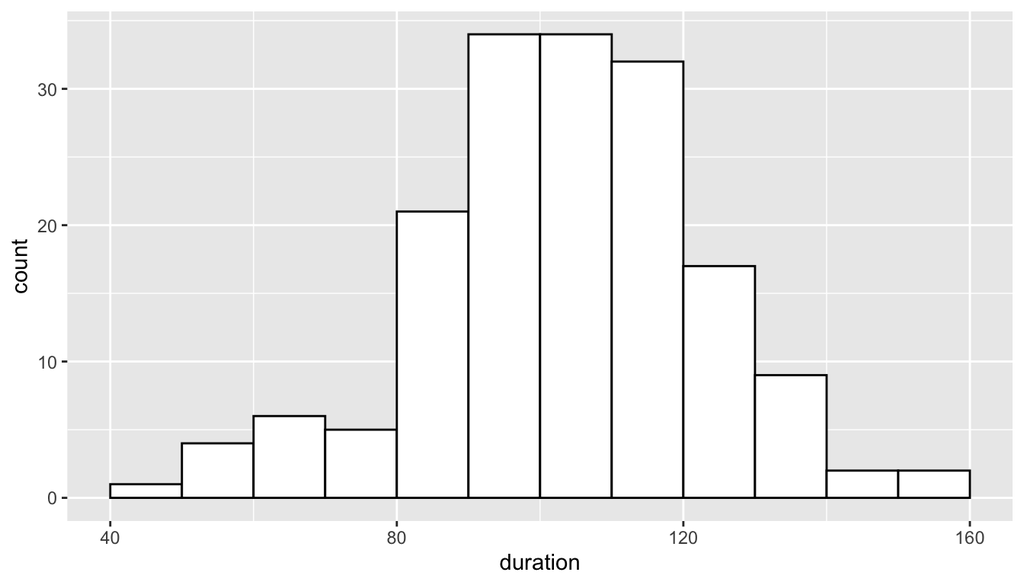

```r
ggplot(monona, aes(x=duration)) +
  geom_histogram(boundary = 0, binwidth = 10,
                 color = "black", fill = "white")
```

In approximately how many winters was the total duration where Lake Monona was at least 50% covered with ice between 40 to 70 days?

### Response

#### Solution

Answer: approximately 11 winters

You can also verify with dplyr commands!

```r
monona %>%
  filter(duration <= 70 & duration > 40) %>%
  nrow()
```

```
## [1] 11
```

2. Modify the code below so that:
- one of the bin boundaries is at 70 days
- the width of each bin is 5 days
- the fill color is “cyan”
- the color outlining the bars is “forestgreen”
- the x label says “Days Closed with Ice”
- the y label says “Total”
- there is a title with words of your choosing that describe the figure

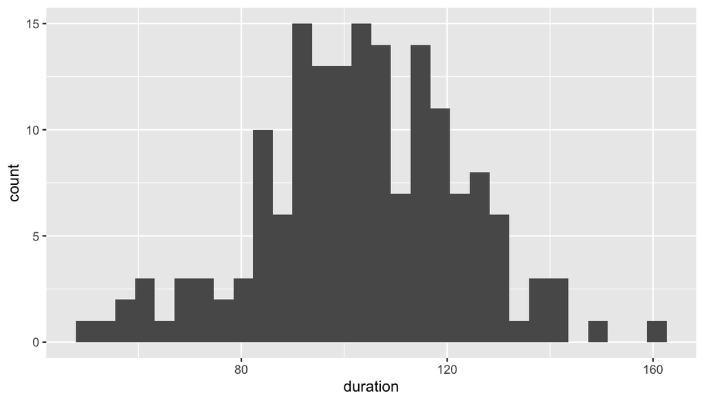

```r
ggplot(monona, aes(x = duration)) +
  geom_histogram()
```

#### Solution

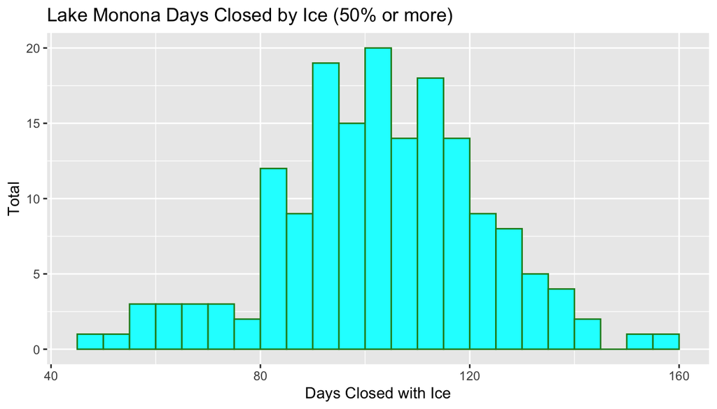

```r
## Answer
ggplot(monona, aes(x = duration)) +
  geom_histogram(boundary=70, binwidth=5,
                 fill="cyan", color="forestgreen") +
  xlab("Days Closed with Ice") +
  ylab("Total") +
  ggtitle("Lake Monona Days Closed by Ice (50% or more)")
```

3. Code in the next chunk makes a scatter plot that shows how the variable `duration` changes with time (using `year1`).

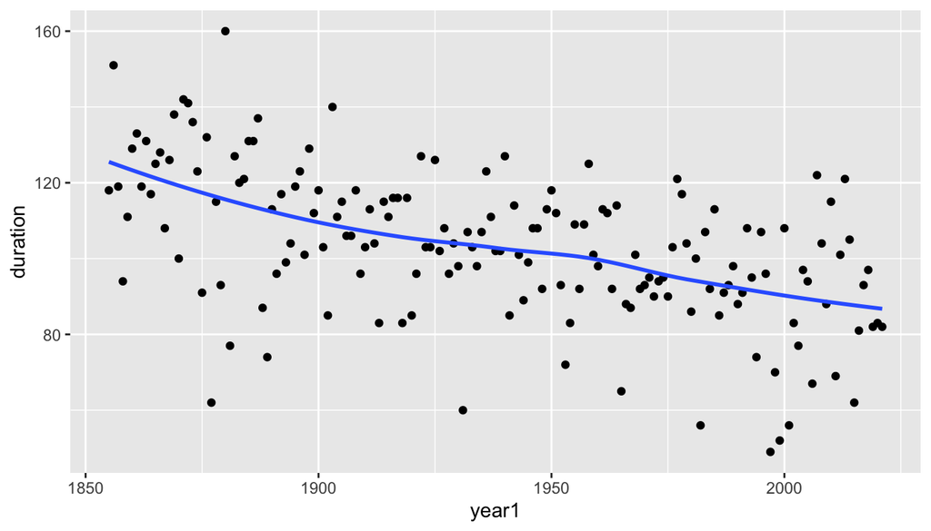

```r
ggplot(monona, aes(x = year1, y = duration)) +
  geom_point() +
  geom_smooth(se=FALSE)
```

- What does the line of code `geom_smooth(se=FALSE)` do? (Explain what it adds to the plot; you don’t need to explain details of the method.)

### Response

#### Solution

> It adds a smooth curve to the plot
- Describe the pattern of the curve.

### Response

#### Solution

> There is a steady decrease from over 120 days in 1855 to under 90 days in 2022
- How long was Lake Monona closed with closed with ice in a typical year near 1875 (i.e., what is the approximate value of the smooth curve around 1875)?

### Response

#### Solution

> Between 115 and 120 days
- How long was Lake Monona closed with ice in a typical year near 2000 (i.e., what is the approximate value of the smooth curve around 2000)?

### Response

#### Solution

> About 90 days
4. Modify the code in the following chunk so that:
- There is a box plot displaying the distribution of the days Lake Monona is closed by ice
- The box plot fill color is “yellow”
- The color of the edges of the box plot is “magenta”
- There is a more descriptive y-axis label
- There is an informative plot title

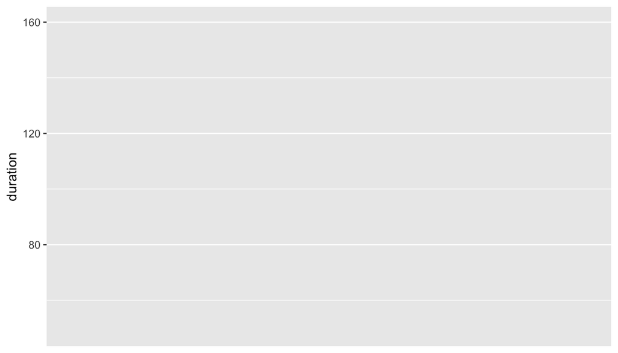

```r
ggplot(monona, aes(y=duration))
```

- What is the approximate median number of days Lake Monona has been closed with ice?

### Response

#### Solution

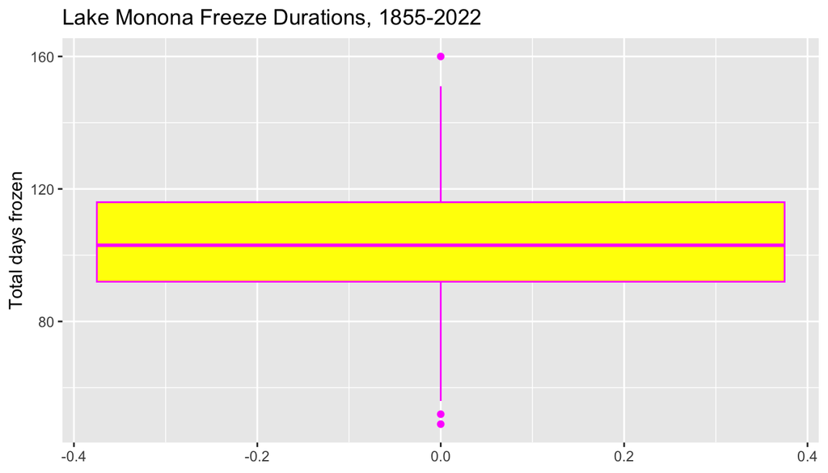

```r
## Answer
ggplot(monona, aes(y=duration)) +
  geom_boxplot(fill="yellow", color="magenta") +
  ylab("Total days frozen") +
  ggtitle("Lake Monona Freeze Durations, 1855-2022")
```

Answer: The median is between 100 and 105 days

5. Write code to create a bar graph which displays the number of winters when the first freeze occured in each half-month period of time as recorded in the variable `ff_cat`. Choose your own colors if you do not like the default values. Make sure that your plot:
- has an informative title and subtitle
- has informative axis labels

#### Solution

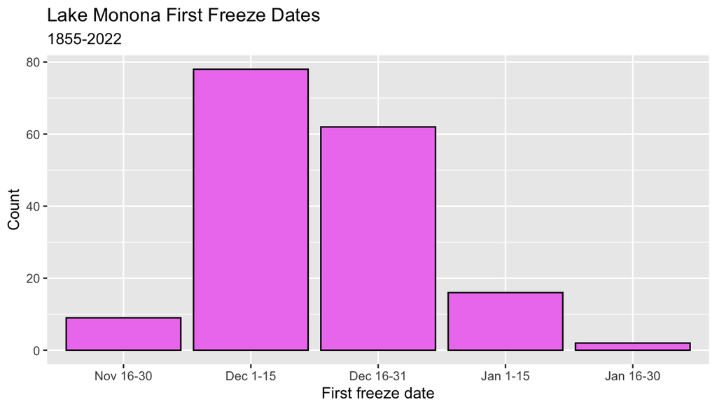

```r
ggplot(monona, aes(x = ff_cat)) +
  geom_bar(color = "black", fill = "violet") +
  xlab("First freeze date") +
  ylab("Count") +
  ggtitle("Lake Monona First Freeze Dates",
          subtitle = "1855-2022")
```

6. Briefly explain why you needed to use the command `geom_bar()` and not `geom_col()` to make the plot in the previous problem.

#### Solution

Answer: The function `geom_bar()` calculates the value of `y`. The function `geom_col()` requires these bar heights to be provided. We made the plot from the original data, not a table of the summarized counts.

7. The following chunk creates a scatter plot with `ff_x` on the x axis and `duration` on the y axis, with points colored by `period50`. The variable `ff_x` is a numerical coding of the first freeze date, counting days after June 30. For context, December 27 is 180 days after June 30. The default color scheme is changed to `viridis` which is friendlier to most people with various forms of color blindness. The command `geom_smooth(method = "lm", se = FALSE)` adds a straight line instead of a curve to the plot (that’s the `method = "lm"` argument) and because we specified `period50` as a grouping variable by mapping it to the color aesthetic, separate lines are added for each group.

Add code to add a plot title and to provide informative axis labels. Following examples from lecture notes, change the title of the color legend to say “Time Period” instead of “period50”.

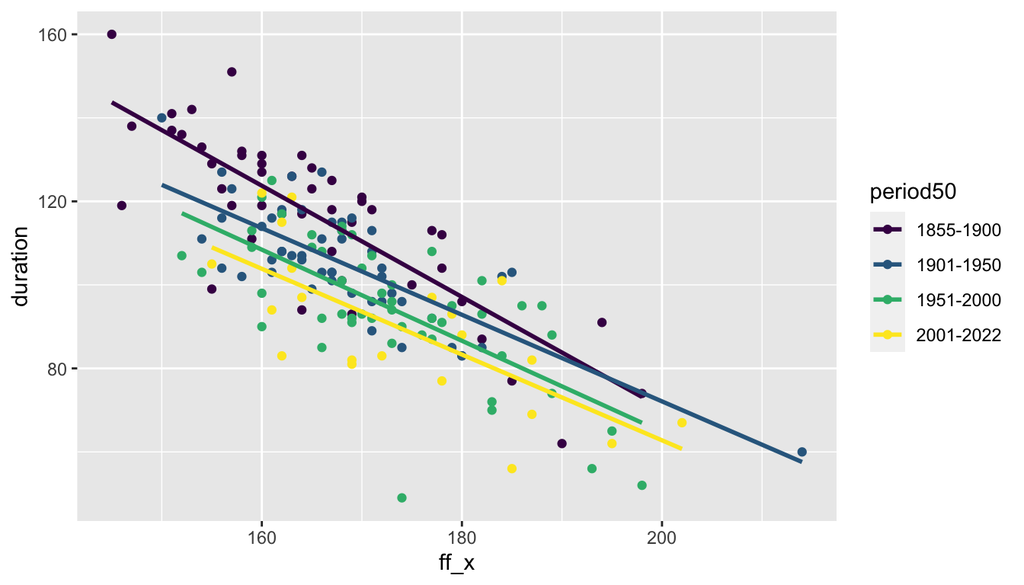

```r
ggplot(monona, aes(x = ff_x, y = duration, color = period50)) +
  geom_point() +
  geom_smooth(se = FALSE, method = "lm") +
  scale_color_viridis_d()
```

After making the graph, suppose that the date of the first freeze in some year was December 27, which is 180 days after June 30. Based on an examination of the graph, briefly explain how your prediction of the total duration that Lake Monona is closed by ice would differ if the winter was in the 1870s versus the present?

#### Solution

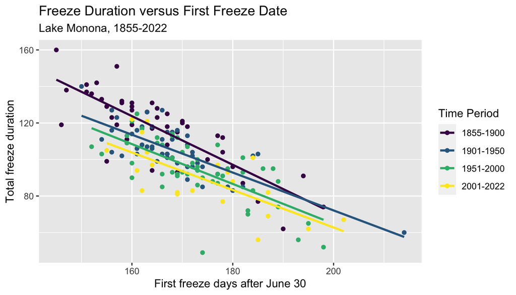

```r
ggplot(monona, aes(x = ff_x, y = duration, color = period50)) +
  geom_point() +
  geom_smooth(se = FALSE, method = "lm") +
  xlab("First freeze days after June 30") +
  ylab("Total freeze duration") +
  ggtitle("Freeze Duration versus First Freeze Date",
          subtitle = "Lake Monona, 1855-2022") +
  scale_color_viridis_d() +
  guides(color = guide_legend(title = "Time Period"))
```

The slopes of the lines are similar in each 50-year period of time, but the lines are lower for more recent periods. In the 1870s, a first freeze on December 27 would lead to a predicted duration of about 95 days whereas in the present, a prediction of about 82 days might be more accurate.

8. The previous plot used color to distinguish which points were in each 50-year period of time. Write code to plot the same data in a scatter plot, but use a different facet (use `facet_wrap()`, following an example in the lecture notes) for each of the four different 50-year periods of time.

Does color or faceting make it easier to compare the relationship between first date of closing with ice and the total duration of the freeze among different 50-year time periods?

#### Solution

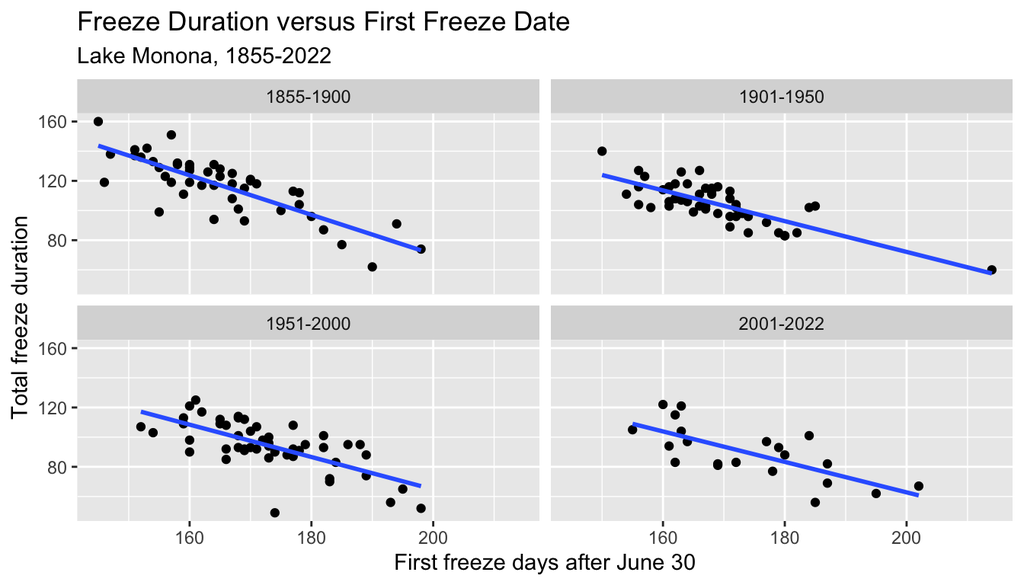

```r
ggplot(monona, aes(x = ff_x, y = duration)) +
  geom_point() +
  geom_smooth(se = FALSE, method = "lm") +
  xlab("First freeze days after June 30") +
  ylab("Total freeze duration") +
  ggtitle("Freeze Duration versus First Freeze Date",
          subtitle = "Lake Monona, 1855-2022") +
  facet_wrap(vars(period50))
```

> Using color on the same plot makes it easier to see that the lines have similar slopes but different intercepts. Here, using faceting makes it hard to see how the durations decrease in more recent time periods.